# SLR and projections

Dr. Wayne Stewart

2018-11-14

# Introduction

We have learn’t about projection matrices in class. Time to trial your knowledge with a simple example. Use the RMD document to place answers under questions.

# The data

We will take data with three components and apply the model
$$Y = X_c\beta +\epsilon$$
This is also written:
$$Y=\theta + \epsilon$$

where $X_c$ is a $3\times 2$ design matrix and $X_r$ is a $3\times 1$ design matrix made soley of 1’s.

The data is:

```r
x=c(2,4,6)
y=c(4,9,20)
```

# The tasks

This is a start to the r code and help to get through this:

```r
library(rgl)
axes3d()
In = matrix(0,nr=3,nc=3)
diag(In)=rep(1,3)
#help(package = "rgl")
arrow3d(c(0,0,0),y, col ="yellow") #y
#planes3d
rglwidget()
```

[interactive chart not shown]

You will make arrows and planes.

## Task 1

Do the following:

1. Describe the column space of $X_c$ and $X_r$.
2. Create the projection matrix $H_c$ – use an R chunk.
3. Create the projection matrix $H_r$ – use an R chunk.
4. Create the projection matrix $I_n - H_c$ – use an R chunk.
5. Create the projection matrix $H_c - H_r$ – use an R chunk.
6. Verify that $H_c-H_r$ is a projection matrix. Use Latex.

## Task 2

On the same graph, plot the following (arrows):

1. The $Y$ vector (has three components)
2. The projection of $Y$ onto the column space of $X_c$.
3. The projection of $Y$ onto the column space of $X_r$

## Task 3

Now add the planes/lines that correspond to the the column space of $X_r$ and $X_c$. Also find the shadow of $Y$ using the projection matrix $H_c-H_r$.

## Task 4

Describe what the final picture means in terms of the $F$ statistic. Start by substituting $n, k$ and $g$.

$$\begin{eqnarray}
F&=& \frac{(SSE_R-SSE_C)/(k-g)}{SSE_C/(n-(k+1))}\\
&=&\frac{\epsilon^{'}(H_c-H_r)\epsilon/(k-g)}{\epsilon^{'}(I_n - H_c)\epsilon/(n-(k+1))}
\end{eqnarray}$$
What does the $F$ stat above (first line) reduce to when the reduced model contains no independent variables. What will $g$ be equal to? What sum of squares will $SSE_R-SSE_C$ become?

$$F=$$

## Task 5

Simulate an F distribution.

Remember:
$$F=\frac{\chi^2_{(1)}/\nu_1}{\chi^2_{(2)}/\nu_2}$$
You can use two different $z^2$ sums to produce the chi squares. Also you may adjust my R code to get the job done or you may also start afresh and make your own function from scratch.

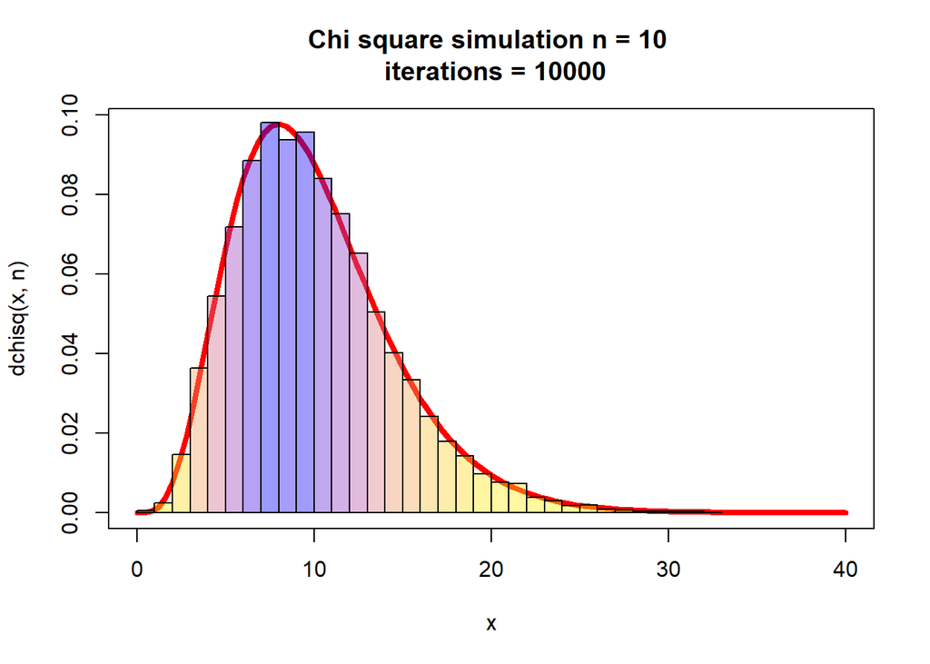

```r
mychi = function(n, iter=1000, ...)
{
  z = rnorm(n*iter,0,1) # simulate z's
  matzsq = matrix(z^2, nr=n,nc=iter) # matrix of z^2
  chisq = apply(matzsq,2,sum) # n z^2 added =chisq n df
  h=hist(chisq,plot=FALSE,...) # grab hist parameters
  coll=h$density/max(h$density) # iter colors between 0 and 1
  curve(dchisq(x,n),xlim = c(0,4*n),col = "Red",main=paste("Chi square simulation", "n =",n,"\n","iterations =", iter), lwd=4)
  hist(chisq,freq=FALSE ,col=rgb(1-coll^3,1-coll,coll,0.4),add=TRUE,...)
  if(n>40)
  {
    curve(dnorm(x,n,sqrt(2*n)), add=TRUE,col = "Blue", lwd = 4)
    text(1.5*n,0.5*max(h$density), "CLT in Blue")
  }

}
mychi(10,10000,nclass=40)
```

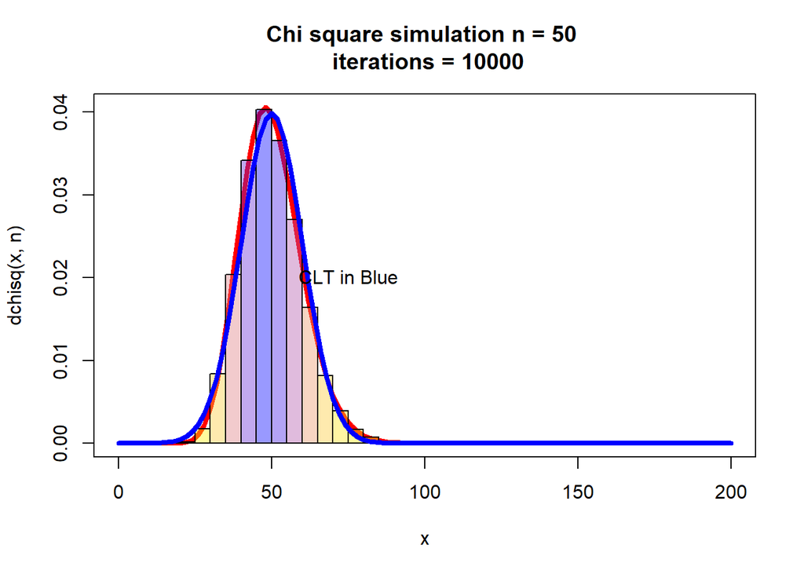

```r
mychi(50,10000)
```